Modelagem

O objetivo deste rmarkdown é realizar a modelagem estatística para a base de dados tratada na etapa de pré-processamento. Para isso, compararemos o desempenho de quatro modelos de regressão com o objetivo de predizer o preço dos imóveis a partir das variáveis preditoras geradas nessa etapa. Os modelos que serão utilizados nesta comparação são:

- Regressão Linear Multivariada
- Regressão Linear Ridge
- Floresta Aleatória
- Gradient Boosting

### Bibliotecas

Carregando as bibliotecas utilizadas no projeto:

```r
library(tidyverse)
library(tidymodels)
library(parsnip)
library(tune)
library(doParallel)
library(ggplot2)
library(rsample)
library(gridExtra)
```

### Carregando base de dados

Importando a base de dados gerada na etapa de pré-processament:

```r
df <- read.csv("data/df_pre_processamento.csv")

df$grupo <- factor(df$grupo)
df$waterfront <- factor(df$waterfront)
df$renovated <- factor(df$renovated)
df$categoria_quartos <- factor(df$categoria_quartos)

rmarkdown::paged_table(head(df))
```

|  | price | bathrooms | sqft_living | floors | waterfront | condition | grade | age | renovated | basement_percent | living_percent | grupo | categoria_quartos |
| --- | --- | --- | --- | --- | --- | --- | --- | --- | --- | --- | --- | --- | --- |
| 1 | 277500 | 2.25 | 1820 | 1 | 0 | 4 | 7 | 50 | 0 | 0.0000000 | 0.09284767 | D | 3 |
| 2 | 250000 | 2.00 | 1660 | 1 | 0 | 3 | 7 | 29 | 0 | 0.3915663 | 0.12686282 | D | 3 |
| 3 | 384000 | 2.75 | 3220 | 2 | 0 | 3 | 9 | 15 | 0 | 0.0000000 | 0.39460784 | D | 5 |
| 4 | 305000 | 1.75 | 2370 | 1 | 0 | 3 | 7 | 47 | 0 | 0.3839662 | 0.23372781 | D | 4 |
| 5 | 265000 | 1.50 | 1780 | 1 | 0 | 4 | 7 | 48 | 0 | 0.2865169 | 0.17457827 | D | 3 |
| 6 | 254000 | 2.00 | 2080 | 1 | 0 | 5 | 7 | 55 | 0 | 0.1634615 | 0.12905628 | D | 5 |

### Métricas de Desempenho

Para a comparação dos modelos, optaremos por utilizar a métrica de Erro Quadrático Médio (EQM). Contudo, dada a grande disparidade de escala na coluna target, representando imóveis com preços bastante distintos, reconhecemos a necessidade de aprimorar a interpretação do EQM. Para abordar esse desafio, calcularemos o EQM em termos percentuais, normalizando o erro pela magnitude dos valores observados. Esta abordagem, conhecida como Erro Percentual, será obtida ao dividir o erro pelo valor real, proporcionando uma visão mais significativa e intuitiva do desempenho dos modelos em cenários com variação expressiva nos preços. Portanto, o dataframe que armazenará os resultados de cada algoritmo incluirá tanto o EQM convencional quanto o EQM percentual, oferecendo uma análise abrangente e aprimorada do desempenho preditivo.

```r
df_results <- data.frame(
    Modelo = c("Linear", "Ridge", "Floresta Aleatória", "Gradient Boosted"),
    EQM = c(NA, NA, NA, NA),
    MAPE = c(NA, NA, NA, NA)
)

rmarkdown::paged_table(head(df_results))
```

|  | Modelo | EQM | MAPE |
| --- | --- | --- | --- |
| 1 | Linear | NA | NA |
| 2 | Ridge | NA | NA |
| 3 | Floresta Aleatória | NA | NA |
| 4 | Gradient Boosted | NA | NA |

### Conjunto de teste e treinamento

Separando os conjuntos de teste e treinamento. Os mesmos conjuntos serão utilizados para comparar o desempenho dos modelos.

No dataframe em questão, há colunas categóricas, como ‘waterfront’, ‘renovated’ e ‘grupo’, que podem complicar a divisão dos conjuntos de teste e treinamento. Se essas colunas exibirem um desequilíbrio considerável, há o risco de certas categorias não serem adequadamente representadas nos conjuntos de teste ou treinamento, o que prejudicaria a eficácia da modelagem.

```r
# Calculando a frequencia relativa da coluna waterfront
prop.table(table(df$waterfront))
```

```
##
##           0           1
## 0.992624749 0.007375251
```

```r
# Calculando a frequencia relativa da coluna waterfront
prop.table(table(df$renovated))
```

```
##
##          0          1
## 0.95766233 0.04233767
```

```r
# Calculando a frequencia relativa da coluna waterfront
prop.table(table(df$grupo))
```

```
##
##         A         B         C         D
## 0.1925034 0.3125146 0.2433833 0.2515987
```

Ao analisar as frequências relativas calculadas para as colunas ‘renovated’ e ‘waterfront’, percebemos que devido a uma categoria apresentar um percentual muito baixo, há o risco de ela ficar sub-representada durante a divisão entre conjuntos de teste e treinamento. Para mitigar esse problema, optaremos por realizar uma estratificação na amostra dos conjuntos de teste e treinamento, assegurando assim a manutenção dessas proporções específicas.

```r
# Criando variavel combinada para estratificação
df$estrato_combinado <- paste(df$waterfront, df$renovated, sep = "_")

# Definindo a semente aletória
set.seed(39)

# Realizando split
split <- initial_split(df, prop=0.8, strata = "estrato_combinado")

# Criando conjuntos de teste e treinemanto
conj_treino <- training(split)
conj_teste <- testing(split)

# Removendo a coluna estrato_combinado
df$estrato_combinado <- NULL
conj_treino$estrato_combinado <- NULL
conj_teste$estrato_combinado <- NULL
```

Com os conjuntos criados, podemos verificar se a estratificação foi eficaz:

Primeiramente para o conjunto de treinamento

```r
# Verificando estratificação do conjunto de treinamento Waterfront
prop.table(table(conj_treino$waterfront))
```

```
##
##           0           1
## 0.992356168 0.007643832
```

```r
# Verificando estratificação do conjunto de treinamento renovated
prop.table(table(conj_treino$renovated))
```

```
##
##         0         1
## 0.9563543 0.0436457
```

Percebe-se que a estratificação foi eficaz para o conjunto de treinamento.

Verificando para o conjunto de teste:

```r
# Verificando estratificação do conjunto de treinamento Waterfront
prop.table(table(conj_teste$waterfront))
```

```
##
##          0          1
## 0.99369895 0.00630105
```

```r
# Verificando estratificação do conjunto de treinamento renovated
prop.table(table(conj_teste$renovated))
```

```
##
##          0          1
## 0.96289382 0.03710618
```

Assim como para o conjunto de treinamento, a estratificação foi satisfatória para o conjunto de teste.

### Definindo receita

Para realizar a modelagem de maneira eficaz, será utilizado a função recipe() da biblioteca tidymodels para normalizar as colunas númericas e criar as váriaveis dummy nas colunas categoricas.

```r
# Receita
receita <- recipe(price ~., data = conj_treino) %>%
            step_normalize(all_numeric(), -all_outcomes()) %>% # Normalizando coluna númericas
            step_dummy(all_nominal(), -all_outcomes()) # Criando variaveis dummy
```

Com a receita definida, podemos realizar o processamento dos dados:

```r
# Preparando a receita
receita_prep <- prep(receita)

# Executando a receita para os conjuntos de teste e treinamento
conj_treino_baked <- bake(receita_prep, new_data = NULL)
conj_teste_baked <- bake(receita_prep, new_data = conj_teste)
```

Observando o processamento do conjunto de treinamento:

```r
rmarkdown::paged_table(head(conj_treino_baked))
```

| bathrooms | sqft_living | floors | condition | grade | age | basement_percent | living_percent | price | waterfront_X1 | renovated_X1 | grupo_B | grupo_C | grupo_D | categoria_quartos_X0 | categoria_quartos_X1 | categoria_quartos_X2 | categoria_quartos_X3 | categoria_quartos_X4 | categoria_quartos_X5 |
| --- | --- | --- | --- | --- | --- | --- | --- | --- | --- | --- | --- | --- | --- | --- | --- | --- | --- | --- | --- |
| -0.1510350 | -0.4643649706 | -0.9182229 | -0.6313154 | -0.5627738 | -0.4857294 | 1.5587477 | -0.7331113 | 250000 | 0 | 0 | 0 | 0 | 1 | 0 | 0 | 0 | 1 | 0 | 0 |
| -0.8066675 | -0.3318083049 | -0.9182229 | 0.9066353 | -0.5627738 | 0.1605562 | 0.9446687 | -0.5567796 | 265000 | 0 | 0 | 0 | 0 | 1 | 0 | 0 | 0 | 1 | 0 | 0 |
| -0.1510350 | -0.0004166405 | -0.9182229 | 2.4445859 | -0.5627738 | 0.3986614 | 0.2253339 | -0.7250054 | 254000 | 0 | 0 | 0 | 0 | 1 | 0 | 0 | 0 | 0 | 0 | 1 |
| -0.4788513 | 0.2646966909 | -0.9182229 | 0.9066353 | 0.2940102 | 0.3986614 | -0.7302002 | -1.0484127 | 541500 | 0 | 0 | 0 | 0 | 1 | 0 | 0 | 0 | 1 | 0 | 0 |
| -0.4788513 | -0.1440196951 | -0.9182229 | -0.6313154 | -0.5627738 | 0.3306313 | 1.9677786 | -0.3755324 | 274000 | 0 | 0 | 0 | 0 | 1 | 0 | 0 | 0 | 0 | 0 | 1 |
| -0.8066675 | -0.9724988560 | -0.9182229 | -0.6313154 | -0.5627738 | -0.5197444 | -0.7302002 | -0.8323824 | 219000 | 0 | 0 | 0 | 0 | 1 | 0 | 0 | 0 | 1 | 0 | 0 |

## Modelagem

Com a receita criada, podemos prosseguir com as modelagens.

### Validação cruzada

Para otmizar alguns dos hiperparametros será utilizado a tecnica de validação cruzada.

```r
# Setando semente aleatória
set.seed(39)

# Criando folds
cv_folds <- vfold_cv(conj_treino, v=10)
```

### Modelo Linear

Primeiro modelo testado será o de regressão linear.

```r
# Especificando o modelo
linear_model <- linear_reg() %>%
  set_engine("lm")

# Ajustando o modelo com o conjunto de treinamento
linear_model_fit <- linear_model %>%
  fit(price ~., data = conj_treino_baked)

summary(linear_model_fit$fit)
```

```
##
## Call:
## stats::lm(formula = price ~ ., data = data)
##
## Residuals:
##      Min       1Q   Median       3Q      Max
## -1021969   -85019    -7470    64874  2018364
##
## Coefficients:
##                      Estimate Std. Error t value Pr(>|t|)
## (Intercept)            697492      11438  60.981  < 2e-16 ***
## bathrooms               22372       2355   9.499  < 2e-16 ***
## sqft_living            179137       2748  65.187  < 2e-16 ***
## floors                 -25620       2195 -11.671  < 2e-16 ***
## condition               18753       1428  13.131  < 2e-16 ***
## grade                   92013       2320  39.668  < 2e-16 ***
## age                     27150       2064  13.155  < 2e-16 ***
## basement_percent       -29927       1705 -17.551  < 2e-16 ***
## living_percent         -15747       1891  -8.328  < 2e-16 ***
## waterfront_X1          710376      15020  47.295  < 2e-16 ***
## renovated_X1            53060       6779   7.827 5.29e-15 ***
## grupo_B               -210968       4181 -50.460  < 2e-16 ***
## grupo_C               -317524       4662 -68.114  < 2e-16 ***
## grupo_D               -426849       4869 -87.674  < 2e-16 ***
## categoria_quartos_X0   233515      50200   4.652 3.32e-06 ***
## categoria_quartos_X1   153919      18087   8.510  < 2e-16 ***
## categoria_quartos_X2   117316      12036   9.747  < 2e-16 ***
## categoria_quartos_X3    93981      11288   8.325  < 2e-16 ***
## categoria_quartos_X4    64740      11034   5.867 4.52e-09 ***
## categoria_quartos_X5    59756      11586   5.158 2.53e-07 ***
## ---
## Signif. codes:  0 '***' 0.001 '**' 0.01 '*' 0.05 '.' 0.1 ' ' 1
##
## Residual standard error: 168600 on 17118 degrees of freedom
## Multiple R-squared:  0.7654, Adjusted R-squared:  0.7651
## F-statistic:  2939 on 19 and 17118 DF,  p-value: < 2.2e-16
```

Observando a coluna Pr(>|t|), percebe-se que todas as variáveis preditoras apresentam a indicação de três asteriscos (***), o que sugere que elas possuem o mais elevado nível de significância contra a hipótese nula de que o coeficiente é zero. Em outras palavras, para o modelo linear simples e sem penalização, todas as variáveis preditoras contribuem significativamente para a predição do preço do imóvel.

Com o modelo treinado, podemos realizar as predições com base no conjunto de teste.

```r
# Realizando a predição
linear_model_predictions <- linear_model_fit %>%
  predict(new_data = conj_teste_baked) %>%
  mutate(observado = conj_teste_baked$price, modelo = "Linear")

# Visualizando as primeiras 10 linhas
rmarkdown::paged_table(linear_model_predictions)
```

| .pred | observado | modelo |
| --- | --- | --- |
| 347382.120 | 277500 | Linear |
| 636453.466 | 384000 | Linear |
| 305326.919 | 305000 | Linear |
| 267680.020 | 250000 | Linear |
| 408893.842 | 328000 | Linear |
| 510615.541 | 465000 | Linear |
| 234092.240 | 239950 | Linear |
| 332510.631 | 246000 | Linear |
| 367945.199 | 289000 | Linear |
| 252067.413 | 314950 | Linear |

[output cut: 4275 more lines]

Cálculando métricas de desempenho.

```r
# Cálculando erro quadrático médio
eqm_linear <- (rmse(linear_model_predictions, observado, .pred)$.estimate)**2

# Cálculando erro percentual absoluto médio(MAPE)
mape_linear <- mean(abs((linear_model_predictions$observado - linear_model_predictions$.pred)/linear_model_predictions$observado)*100)

# Adicionando resultados para o df de comparação
df_results[df_results$Modelo == "Linear", "EQM"] <- eqm_linear
df_results[df_results$Modelo == "Linear", "MAPE"] <- mape_linear

rmarkdown::paged_table(df_results)
```

| Modelo | EQM | MAPE |
| --- | --- | --- |
| Linear | 28928902495 | 22.16784 |
| Ridge | NA | NA |
| Floresta Aleatória | NA | NA |
| Gradient Boosted | NA | NA |

Observando os resultados para o modelo linear, este algoritmo tem um erro médio de aproximadamente 22%.

### Ridge

Realizando a modelagem de regrssão com penalização ridge.

Primeiramente, iremos especificar o modelo.

```r
# Especificando o modelo
ridge_model <- linear_reg(penalty = tune(), mixture = 0, mode = "regression") %>%
  set_engine("glmnet")

# Definindo os valores de lambda que serão testados
lambda_values <- tibble(penalty = c(0.0001, 0.001, 0.01, 0.1, 1, 2, 5, 10, 15, 30, 1000, 10000, 100000))

# Criando grid
grid_ridge_result <- tune_grid(
  ridge_model,
  receita,
  resamples = cv_folds,
  grid = lambda_values
)

# Visualize os resultados
grid_ridge_result %>%
  collect_metrics() %>%
  filter(.metric == "rmse") %>%
  arrange(mean)
```

```
## # A tibble: 13 × 7
##        penalty .metric .estimator    mean     n std_err .config
##          <dbl> <chr>   <chr>        <dbl> <int>   <dbl> <chr>
##  1      0.0001 rmse    standard   171983.    10   2113. Preprocessor1_Model01
##  2      0.001  rmse    standard   171983.    10   2113. Preprocessor1_Model02
##  3      0.01   rmse    standard   171983.    10   2113. Preprocessor1_Model03
##  4      0.1    rmse    standard   171983.    10   2113. Preprocessor1_Model04
##  5      1      rmse    standard   171983.    10   2113. Preprocessor1_Model05
##  6      2      rmse    standard   171983.    10   2113. Preprocessor1_Model06
##  7      5      rmse    standard   171983.    10   2113. Preprocessor1_Model07
##  8     10      rmse    standard   171983.    10   2113. Preprocessor1_Model08
##  9     15      rmse    standard   171983.    10   2113. Preprocessor1_Model09
## 10     30      rmse    standard   171983.    10   2113. Preprocessor1_Model10
## 11   1000      rmse    standard   171983.    10   2113. Preprocessor1_Model11
## 12  10000      rmse    standard   171983.    10   2113. Preprocessor1_Model12
## 13 100000      rmse    standard   185886.    10   2413. Preprocessor1_Model13
```

```r
ridge_model_final <- ridge_model %>%
  finalize_model(tibble(penalty = 0.0001)) %>%
  fit(price ~., data=conj_treino_baked)

coef(ridge_model_final$fit, s = 0.0001)
```

```
## 20 x 1 sparse Matrix of class "dgCMatrix"
##                               s1
## (Intercept)           699767.861
## bathrooms              29764.720
## sqft_living           144590.938
## floors                -12288.420
## condition              18108.913
## grade                 105631.594
## age                    40100.284
## basement_percent      -17462.137
## living_percent        -10035.321
## waterfront_X1         668705.727
## renovated_X1           54228.905
## grupo_B              -134122.056
## grupo_C              -229397.404
## grupo_D              -332065.792
## categoria_quartos_X0  155561.745
## categoria_quartos_X1   72108.514
## categoria_quartos_X2   39279.419
## categoria_quartos_X3   15679.978
## categoria_quartos_X4    -777.545
## categoria_quartos_X5    6361.207
```

Com o hiperparametro otimizado, podemos realizar as predições do conjunto de teste e cálcular as métrica de desempenho.

```r
# Realizando a predição
ridge_model_predictions <- ridge_model_final %>%
  predict(new_data = conj_teste_baked) %>%
  mutate(observado = conj_teste_baked$price, modelo = "Ridge")

# Visualizando as primeiras 10 linhas
rmarkdown::paged_table(ridge_model_predictions)
```

| .pred | observado | modelo |
| --- | --- | --- |
| 345846.942 | 277500 | Ridge |
| 651164.168 | 384000 | Ridge |
| 321359.745 | 305000 | Ridge |
| 287061.442 | 250000 | Ridge |
| 402575.892 | 328000 | Ridge |
| 548112.727 | 465000 | Ridge |
| 270478.536 | 239950 | Ridge |
| 352141.569 | 246000 | Ridge |
| 367056.973 | 289000 | Ridge |
| 279353.256 | 314950 | Ridge |

[output cut: 4275 more lines]

Cálculando métricas de desempenho.

```r
# Cálculando erro quadrático médio
eqm_ridge <- (rmse(ridge_model_predictions, observado, .pred)$.estimate)**2

# Cálculando erro percentual absoluto médio(MAPE)
mape_ridge <- mean(abs((ridge_model_predictions$observado - ridge_model_predictions$.pred)/ridge_model_predictions$observado)*100)

# Adicionando resultados para o df de comparação
df_results[df_results$Modelo == "Ridge", "EQM"] <- eqm_ridge
df_results[df_results$Modelo == "Ridge", "MAPE"] <- mape_ridge

rmarkdown::paged_table(df_results)
```

| Modelo | EQM | MAPE |
| --- | --- | --- |
| Linear | 28928902495 | 22.16784 |
| Ridge | 29804656359 | 21.14221 |
| Floresta Aleatória | NA | NA |
| Gradient Boosted | NA | NA |

Como já era esperado pelo resultado observado na validação cruzada, a penalização não ofereceu nenhuma vantagem significativa para o modelo.

### Random Forest

Modelagem utilizando o método de árvores aleatórias.

```r
# Especificando o modelo
rf_model <- rand_forest(
  trees = tune(),
  mtry = tune(),
  min_n = tune()
) %>%
  set_mode("regression") %>%
  set_engine("ranger")
```

Definindo o grid de valores que serão testados.

```r
rf_grid <- expand.grid(
  trees = c(50, 100, 200, 500),
  mtry = c(2, 3, sqrt(ncol(training_data)-1)), # 2, 3 e raiz quadrada do nº de preditores
  min_n = c(10, 15, 30)
)
```

A estratégia para otimizar esses hiperparametros será a validação cruzada para 10 lotes, assim como foi realizado para o Ridge. Para está etapa utilizaremos um conceito de escalabilidade horizontal, paralelizando o código com o intuito aumentar a velocidade de processamento desta validação cruzada.

```r
# Paralelizando para obter um processamento mais rápido

# Determinar o número de núcleos a serem utilizados
#num_cores <- detectCores() - 1 # deixando um núcleo livre

# Registrar o backend paralelo
#registerDoParallel(cores = num_cores)

# Realizando a otimização
#grid_rf_result <- tune_grid(
  #rf_model,
  #receita,
  #resamples = cv_folds
#)

# Finalizando a paralelização após a conclusão da tarefa
#stopImplicitCluster()
```

```r
# Visualize os resultados
#grid_rf_result %>%
  #collect_metrics() %>%
  #filter(.metric == "rmse") %>%
  #arrange(mean)
```

Com as combinações cálculadas, retreinamos o modelo com esses hiperparametros.

```r
# Melhor combinação
#rf_best_hip <- select_best(grid_rf_result, "rmse")

# Salvando hiperparametros otimizados em um arquivo CSV
#write_csv(rf_best_hip, "data/rf_best_hip.csv")

#rf_best_hip
```

**OBS :Como o tempo de processamento é elevado para o modelo de Floresta Aleatória, os hiperparamentros otimizados serão salvos em um arquivo csv para não ser preciso rodar todas as interações novamente**

```r
# Lendo arquivo CSV com hiperparametros otimizados
rf_best_hip <- read.csv("data/rf_best_hip.csv")

rf_best_hip
```

```
##   mtry trees min_n               .config
## 1   10   362    11 Preprocessor1_Model01
```

```r
rf_model_final <- rf_model %>%
  finalize_model(rf_best_hip) %>%
  fit(price ~., data = conj_treino_baked)
```

Assim, será cálculado as predições para o conjunto de teste e a métrica de desempenho do modelo.

```r
# Realizando a predição
rf_model_predictions <- rf_model_final %>%
  predict(new_data = conj_teste_baked) %>%
  mutate(observado = conj_teste_baked$price, modelo = "Floresta Aleatória")

# Visualizando as primeiras 10 linhas
rmarkdown::paged_table(rf_model_predictions)
```

| .pred | observado | modelo |
| --- | --- | --- |
| 278471.9 | 277500 | Floresta Aleatória |
| 471756.9 | 384000 | Floresta Aleatória |
| 306841.1 | 305000 | Floresta Aleatória |
| 264944.0 | 250000 | Floresta Aleatória |
| 348604.9 | 328000 | Floresta Aleatória |
| 411055.5 | 465000 | Floresta Aleatória |
| 273645.0 | 239950 | Floresta Aleatória |
| 300474.5 | 246000 | Floresta Aleatória |
| 302642.7 | 289000 | Floresta Aleatória |
| 289579.9 | 314950 | Floresta Aleatória |

[output cut: 4275 more lines]

Cálculando métricas de desempenho.

```r
# Cálculando erro quadrático médio
eqm_rf <- (rmse(rf_model_predictions, observado, .pred)$.estimate)**2

# Cálculando erro percentual absoluto médio(MAPE)
mape_rf <- mean(abs((rf_model_predictions$observado - rf_model_predictions$.pred)/rf_model_predictions$observado)*100)

# Adicionando resultados para o df de comparação
df_results[df_results$Modelo == "Floresta Aleatória", "EQM"] <- eqm_rf
df_results[df_results$Modelo == "Floresta Aleatória", "MAPE"] <- mape_rf

rmarkdown::paged_table(df_results)
```

| Modelo | EQM | MAPE |
| --- | --- | --- |
| Linear | 28928902495 | 22.16784 |
| Ridge | 29804656359 | 21.14221 |
| Floresta Aleatória | 18564534394 | 15.26592 |
| Gradient Boosted | NA | NA |

Ao observar o resultado preditivo da floresta aleatória percebe-se uma melhora significativa.

### Gradient Boosted Decision Trees

O último modelo que será testado é o gradient boosting.

```r
# Especificando o modelo
boosting_model <- boost_tree(
  trees = tune(),
  tree_depth = tune(),
  learn_rate = tune(),
  loss_reduction = tune(),
  sample_size = tune()
) %>%
  set_mode("regression") %>%
  set_engine("xgboost")
```

Criando grade de hiperparametros

```r
# Definindo a especificação dos parâmetros
#param_spec <- parameters(boosting_model)

# Criar a grade aleatória
#set.seed(39) # para reprodutibilidade
#random_grid <- grid_random(param_spec, size = 50) # cria 50 combinações aleatórias
```

a grade de hiperparametros ajustada, podemos realizar a validação cruzada para encontrar a melhor combinação. Ressaltando que também utilizaremos a paralelização do código para obter um processamento mais rapido.

```r
# Configurando a semente para reprodutibilidade
#set.seed(39)

# Configurando a paralelização
#num_cores <- detectCores() - 1 # deixando um núcleo livre
#registerDoParallel(cores = num_cores)

# Medindo o tempo de execução e realizando a validação cruzada

#grid_boosting_results <- tune_grid(
  #boosting_model,
  #receita,
  #resamples = cv_folds,
  #)

# Finalizando a paralelização
#stopImplicitCluster()
```

```r
# Melhor combinação
#boosting_best_hip <- select_best(grid_boosting_results, "rmse")

# Salvando em um arquivo csv
#write_csv(boosting_best_hip, "data/boosting_best_hip.csv")

#boosting_best_hip
```

**OBS:Como o tempo de processamento é elevado para o modelo do XGboosting, os hiperparamentros otimizados serão salvos em um arquivo csv para não ser preciso rodar todas as interações novamente**

```r
# Lendo os hiperparametros otimizados
boosting_best_hip <- read.csv("data/boosting_best_hip.csv")

# Visualizando
rmarkdown::paged_table(boosting_best_hip)
```

| trees | tree_depth | learn_rate | loss_reduction | sample_size | .config |
| --- | --- | --- | --- | --- | --- |
| 501 | 7 | 0.0159987 | 5.76918e-07 | 0.4238235 | Preprocessor1_Model05 |

A partir dos hiperparametros otimizados, o modelo será retreinado.

```r
# Configurando semente aleatoria
set.seed(39)

boosting_model_final <- boosting_model %>%
  finalize_model(boosting_best_hip) %>%
  fit(price ~., data = conj_treino_baked)
```

Realizando as predições utilizando o conjunto de teste e calcular a métrica de desempenho.

```r
# Realizando a predição
boosting_model_predictions <- boosting_model_final %>%
  predict(new_data = conj_teste_baked) %>%
  mutate(observado = conj_teste_baked$price, modelo = "Gradient_Boosting")

# Visualizando as primeiras 10 linhas
rmarkdown::paged_table(boosting_model_predictions)
```

| .pred | observado | modelo |
| --- | --- | --- |
| 288048.7 | 277500 | Gradient_Boosting |
| 468565.2 | 384000 | Gradient_Boosting |
| 301728.8 | 305000 | Gradient_Boosting |
| 270071.3 | 250000 | Gradient_Boosting |
| 334467.2 | 328000 | Gradient_Boosting |
| 465156.5 | 465000 | Gradient_Boosting |
| 263699.3 | 239950 | Gradient_Boosting |
| 282333.8 | 246000 | Gradient_Boosting |
| 303581.0 | 289000 | Gradient_Boosting |
| 275355.1 | 314950 | Gradient_Boosting |

[output cut: 4275 more lines]

```r
# Cálculando erro quadrático médio
eqm_boosting <- (rmse(boosting_model_predictions, observado, .pred)$.estimate)**2

# Cálculando erro percentual absoluto médio(MAPE)
mape_boosting <- mean(abs((boosting_model_predictions$observado - boosting_model_predictions$.pred)/boosting_model_predictions$observado)*100)

# Adicionando resultados para o df de comparação
df_results[df_results$Modelo == "Gradient Boosted", "EQM"] <- eqm_boosting
df_results[df_results$Modelo == "Gradient Boosted", "MAPE"] <- mape_boosting

rmarkdown::paged_table(df_results)
```

| Modelo | EQM | MAPE |
| --- | --- | --- |
| Linear | 28928902495 | 22.16784 |
| Ridge | 29804656359 | 21.14221 |
| Floresta Aleatória | 18564534394 | 15.26592 |
| Gradient Boosted | 18022996668 | 15.14011 |

## Comparação de desempenhos entre modelos

Com as métricas de desempenho cálculadas para os quatro modelos, chegamos na seguinte tabela de erro:

```r
rmarkdown::paged_table(df_results)
```

| Modelo | EQM | MAPE |
| --- | --- | --- |
| Linear | 28928902495 | 22.16784 |
| Ridge | 29804656359 | 21.14221 |
| Floresta Aleatória | 18564534394 | 15.26592 |
| Gradient Boosted | 18022996668 | 15.14011 |

Para entender como o erro se comporta em cada modelo, iremos analisar as distribuições percentuais.

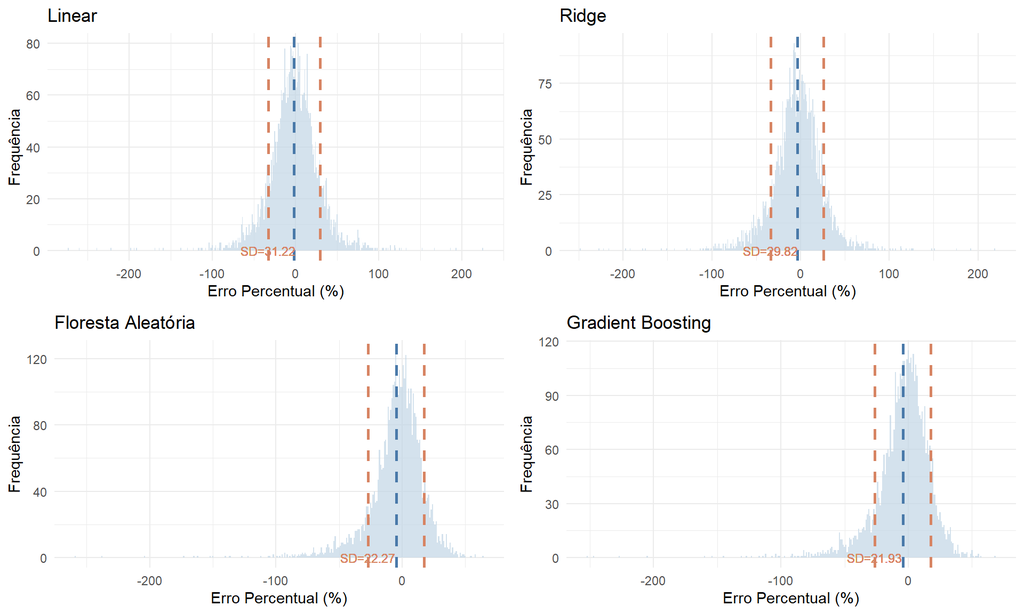

```r
# Cálculando o erro percentual para cada observação
# Linear
linear_model_predictions$mpe <- ((linear_model_predictions$observado - linear_model_predictions$.pred)/linear_model_predictions$observado)*100
# Ridge
ridge_model_predictions$mpe <- ((ridge_model_predictions$observado - ridge_model_predictions$.pred)/ridge_model_predictions$observado)*100
# Floresta Aleatoria
rf_model_predictions$mpe <- ((rf_model_predictions$observado - rf_model_predictions$.pred)/rf_model_predictions$observado)*100
# Gradient Boosted
boosting_model_predictions$mpe <- ((boosting_model_predictions$observado - boosting_model_predictions$.pred)/boosting_model_predictions$observado)*100

# Cálculando média e desvio padrão
# Linear
linear_mpe_mean <- mean(linear_model_predictions$mpe)
linear_mpe_desv <- sd(linear_model_predictions$mpe)
# Ridge
ridge_mpe_mean <- mean(ridge_model_predictions$mpe)
ridge_mpe_desv <- sd(ridge_model_predictions$mpe)
# Floresta Aleatória
rf_mpe_mean <- mean(rf_model_predictions$mpe)
rf_mpe_desv <- sd(rf_model_predictions$mpe)
# Gradient Boosting
boosting_mpe_mean <- mean(boosting_model_predictions$mpe)
boosting_mpe_desv <- sd(boosting_model_predictions$mpe)

# Plotando as distribuições
# Histograma Modelo Linear
linear_hist <- ggplot(linear_model_predictions, aes(x = mpe)) +
  geom_histogram(binwidth = 1, fill = "#C1D6E5", alpha = 0.7) +
  geom_vline(xintercept = linear_mpe_mean, color = "#4979A9", linetype = "dashed", linewidth = 1) +
  geom_vline(xintercept = c(linear_mpe_mean - linear_mpe_desv, linear_mpe_mean + linear_mpe_desv), color = "#D78463", linetype = "dashed", linewidth = 1) +
  geom_text(x = linear_mpe_mean - linear_mpe_desv, y = 0, label = sprintf("SD=%.2f", linear_mpe_desv), color = "#D78463", size = 3) +
  theme_minimal() +
  labs(
    title = "Linear",
    x = "Erro Percentual (%)",
    y = "Frequência"
  )

# Histograma Modelo Ridge
ridge_hist <- ggplot(ridge_model_predictions, aes(x = mpe)) +
  geom_histogram(binwidth = 1, fill = "#C1D6E5", alpha = 0.7) +
  geom_vline(xintercept = ridge_mpe_mean, color = "#4979A9", linetype = "dashed", linewidth = 1) +
  geom_vline(xintercept = c(ridge_mpe_mean - ridge_mpe_desv, ridge_mpe_mean + ridge_mpe_desv), color = "#D78463", linetype = "dashed", linewidth = 1) +
  geom_text(x = ridge_mpe_mean - ridge_mpe_desv, y = 0, label = sprintf("SD=%.2f", ridge_mpe_desv), color = "#D78463", size = 3) +
  theme_minimal() +
  labs(
    title = "Ridge",
    x = "Erro Percentual (%)",
    y = "Frequência"
  )

# Histograma Modelo Floresta Aleatória
rf_hist <- ggplot(rf_model_predictions, aes(x = mpe)) +
  geom_histogram(binwidth = 1, fill = "#C1D6E5", alpha = 0.7) +
  geom_vline(xintercept = rf_mpe_mean, color = "#4979A9", linetype = "dashed", linewidth = 1) +
  geom_vline(xintercept = c(rf_mpe_mean - rf_mpe_desv, rf_mpe_mean + rf_mpe_desv), color = "#D78463", linetype = "dashed", linewidth = 1) +
  geom_text(x = rf_mpe_mean - rf_mpe_desv, y = 0, label = sprintf("SD=%.2f", rf_mpe_desv), color = "#D78463", size = 3) +
  theme_minimal() +
  labs(
    title = "Floresta Aleatória",
    x = "Erro Percentual (%)",
    y = "Frequência"
  )

# Histograma Modelo Gradient Boosting
boosting_hist <- ggplot(boosting_model_predictions, aes(x = mpe)) +
  geom_histogram(binwidth = 1, fill = "#C1D6E5", alpha = 0.7) +
  geom_vline(xintercept = boosting_mpe_mean, color = "#4979A9", linetype = "dashed", linewidth = 1) +
  geom_vline(xintercept = c(boosting_mpe_mean - boosting_mpe_desv, boosting_mpe_mean + boosting_mpe_desv), color = "#D78463", linetype = "dashed", linewidth = 1) +
  geom_text(x = boosting_mpe_mean - boosting_mpe_desv, y = 0, label = sprintf("SD=%.2f", boosting_mpe_desv), color = "#D78463", size = 3) +
  theme_minimal() +
  labs(
    title = "Gradient Boosting",
    x = "Erro Percentual (%)",
    y = "Frequência"
  )

# Criando matriz de plot com gridExtra
combined_hist <- grid.arrange(linear_hist, ridge_hist, rf_hist, boosting_hist, ncol = 2, nrow = 2)
```

```r
# Exibindo os gráficos combinados
print(combined_hist)
```

Como temos uma diferença de escala significativa no preço dos imóveis desta base de dados, iremo analisar a capacidade de cada modelo em acertar a predição conforme o preço do imóvel aumenta.

[figure not shown]

```r
# Gráfico linear
linear_plot1 <- ggplot(linear_model_predictions, aes(x=observado, y=mpe)) +
  geom_point(aes(color = mpe)) +
  geom_hline(yintercept=0, linetype="dashed", color="#D78463") +
  scale_color_gradient(low = "#C1D6E5", high = "#4979A9") +  # Adicionado esta linha
  theme_minimal() +
  labs(
    title = "Linear",
    x = "Valores Observadoss",
    y = "Resíduos Percentuais",
    color = "Resíduo"
  )

# Gráfico Ridge
ridge_plot1 <- ggplot(ridge_model_predictions, aes(x=observado, y=mpe)) +
  geom_point(aes(color = mpe)) +
  geom_hline(yintercept=0, linetype="dashed", color="#D78463") +
  scale_color_gradient(low = "#C1D6E5", high = "#4979A9") +  # Adicionado esta linha
  theme_minimal() +
  labs(
    title = "Lasso",
    x = "Valores Observados",
    y = "Resíduos Percentuais",
    color = "Resíduo"
  )

# Random Forest
rf_plot1 <- ggplot(rf_model_predictions, aes(x=observado, y=mpe)) +
  geom_point(aes(color = mpe)) +
  geom_hline(yintercept=0, linetype="dashed", color="#D78463") +
  scale_color_gradient(low = "#C1D6E5", high = "#4979A9") +  # Adicionado esta linha
  theme_minimal() +
  labs(
    title = "Random Forest",
    x = "Valores Observados",
    y = "Resíduos Percentuais",
    color = "Resíduo"
  )

# Gradient Boosting
boosting_plot1 <- ggplot(boosting_model_predictions, aes(x=observado, y=mpe)) +
  geom_point(aes(color = mpe)) +
  geom_hline(yintercept=0, linetype="dashed", color="#D78463") +
  scale_color_gradient(low = "#C1D6E5", high = "#4979A9") +  # Adicionado esta linha
  theme_minimal() +
  labs(
    title = "Boosting",
    x = "Valores Observados",
    y = "Resíduos Percentuais",
    color = "Resíduo"
  )

# Criando matriz de plot com gridExtra
combined_hist <- grid.arrange(linear_plot1, ridge_plot1, rf_plot1, boosting_plot1, ncol = 2, nrow = 2)
```

```r
# Exibindo os gráficos combinados
print(combined_hist)
```

Ao analisar o gráfico gerado, nota-se que todos os modelos apresentaram erros elevados em algumas observações de apartamentos com valores mais baixos. Além disso, o gráfico também demonstrou o que havia sido descrito anteriormente de que os modelos baseados em árvores conseguiram corrigir os erros percentuais das observações subestimadas. No entanto, esses modelos ainda enfrentaram problemas ao predizer de maneira superestimada o preço de algumas poucas observações.

## Comparando modelos com e sem clusterização

Com o objetivo de avaliar a contribuição da análise não supervisionada de agrupamento realizada na etapa de pré-processamento, foram aplicados os modelos de regressão no dataset que mantém as colunas de latitude, longitude e zipcode. Abaixo, uma visualização do dataframe sem clusterização:

```r
df_semcluster <- read.csv("data/df_pre_processamento_semcluster.csv")

rmarkdown::paged_table(head(df_semcluster))
```

|  | price | bathrooms | sqft_living | floors | waterfront | condition | grade | zipcode | lat | long | age | renovated | basement_percent | living_percent | categoria_quartos |
| --- | --- | --- | --- | --- | --- | --- | --- | --- | --- | --- | --- | --- | --- | --- | --- |
| 1 | 300000 | 3.00 | 2400 | 2.0 | 0 | 3 | 7 | 98002 | 47.3262 | -122.214 | 24 | 0 | 0.0000000 | 0.25605462 | >5 |
| 2 | 647500 | 1.75 | 2060 | 1.0 | 0 | 4 | 8 | 98166 | 47.4444 | -122.351 | 67 | 0 | 0.4368932 | 0.07912122 | 4 |
| 3 | 400000 | 1.00 | 1460 | 1.0 | 0 | 3 | 7 | 98166 | 47.4434 | -122.347 | 62 | 0 | 0.0000000 | 0.03395349 | 3 |
| 4 | 235000 | 1.00 | 1430 | 1.5 | 0 | 4 | 6 | 98168 | 47.4783 | -122.265 | 85 | 0 | 0.2937063 | 0.18818266 | 3 |
| 5 | 402500 | 2.00 | 1650 | 1.0 | 0 | 3 | 7 | 98144 | 47.5803 | -122.294 | 64 | 1 | 0.5393939 | 0.47089041 | 4 |
| 6 | 680000 | 2.75 | 2220 | 1.0 | 0 | 5 | 7 | 98144 | 47.5801 | -122.294 | 64 | 0 | 0.4729730 | 0.41807910 | 4 |

Para esse comparativo, foram otimizados novamente os hiperparâmetros da floresta aleatória e do boosting, de modo a compreendermos o potencial da modelagem sem a análise não supervisionada. Os resultados podem ser observados abaixo:

```r
# Lendo arquivo csv
df_semcluster_results <- read.csv("data/df_semcluster_results.csv")

# Visualização
rmarkdown::paged_table(df_semcluster_results)
```

| Modelo | EQM | MAPE |
| --- | --- | --- |
| Linear | 23550822604 | 19.43393 |
| Ridge | 23879513195 | 18.80380 |
| Floresta Aleatória | 14796974568 | 12.69010 |
| Gradient Boosted | 11525781926 | 11.88556 |

Criando uma tabela de comparação percentual no ganho de predição ao não utilizar a clusterização:

```r
# Criando função do calculo percentual de EQM e MAPE
comp_calc <- function(modelo, metrica) {
  resultado <- ((df_results[df_results$Modelo == modelo, metrica] - df_semcluster_results[df_semcluster_results$Modelo == modelo, metrica])/df_results[df_results$Modelo == modelo, metrica])*100
  return(resultado)
}


# Criando dataframe de comparação
df_cluster_compare <- data.frame(
    Modelo = c("Linear", "Ridge", "Floresta Aleatória", "Gradient Boosted"),
    EQM_percent = c(comp_calc("Linear", "EQM"), comp_calc("Ridge", "EQM"), comp_calc('Floresta Aleatória', "EQM"), comp_calc("Gradient Boosted", "EQM")),
    MAPE_percent = c(comp_calc("Linear", "MAPE"), comp_calc("Ridge", "MAPE"), comp_calc('Floresta Aleatória', "MAPE"), comp_calc("Gradient Boosted", "MAPE"))
)

# Visualizando os resultados
rmarkdown::paged_table(df_cluster_compare)
```

| Modelo | EQM_percent | MAPE_percent |
| --- | --- | --- |
| Linear | 18.59068 | 12.33277 |
| Ridge | 19.87992 | 11.06041 |
| Floresta Aleatória | 20.29439 | 16.87299 |
| Gradient Boosted | 36.04958 | 21.49621 |